# xwMOOC 모형

고객이탈 - RESTful API 기본기 `plumber`

xwMOOC

Tidyverse Korea

2019-11-24

# 1 `plumber` 헬로 월드

[`plumber` - An R package that converts your existing R code to a web API using a handful of special one-line comments.](https://www.rplumber.io/)에 나와 있는 `plumber` 예제를 바탕으로 RESTful API를 헬로월드를 작성한다.

**`plumber` 실행파일**

`main()` 함수처럼 개발된 RESTful API를 실행시키는 파일.

```r
library(plumber)
r <- plumb("deploy/plumber.R")
r$run(port=8000)
```

**RESTful API 서비스 파일**

```r
library(tidyverse)

#* Echo back the input
#* @param msg The message to echo
#* @get /echo
function(msg=""){
  list(msg = paste0("The message is: '", msg, "'"))
}

#* Plot a histogram with ggplot
#* @png
#* @get /ggplot
function() {
  p <- data.frame(x = rnorm(100)) %>%
    ggplot(aes(x)) +
      geom_density(fill = "tomato", alpha = 0.5)
  print(p)
}

#* Plot a histogram with Base plot
#* @png
#* @get /plot
function(){
  rand <- rnorm(100)
  hist(rand)
}


#* Return the sum of two numbers
#* @param a The first number to add
#* @param b The second number to add
#* @post /sum
function(a=1, b=2){
  as.numeric(a) + as.numeric(b)
}

#* Return the sum of two numbers
#* @param a The first number to add
#* @param b The second number to add
#* @get /sum_two
function(a, b){
  as.numeric(a) + as.numeric(b)
}
```

## 1.1 `/echo` 메시지 서비스

가장 먼저 웹브라우저 주소창에 `http://localhost:8000/echo?msg="Hello_World"`을 입력시켰을 때 `msg` 매개변수로 “Hello_World”를 전달했을 때 이를 메아리치는 경우를 구현해보자.

```r
library(httr)
library(tidyverse)
GET('http://localhost:8000/echo?msg="Hello_World"') %>%
  content()
```

```
$msg
$msg[[1]]
[1] "The message is: '\"Hello_World\"'"
```

## 1.2 `/plot` 그래프

`/plot` 시각화를 위해서 몇가지 조작을 해야는데 먼저 `/ggplot`으로 서비스를 준비한다. Rmarkdown 이미지를 넣기 위해서 `plot(0:1, 0:1, type = "n")` 사전 설정을 하고, `rasterImage(0, 0, 1, 1)`를 통해 숫자로 나온 결과를 시각화 시킨다.

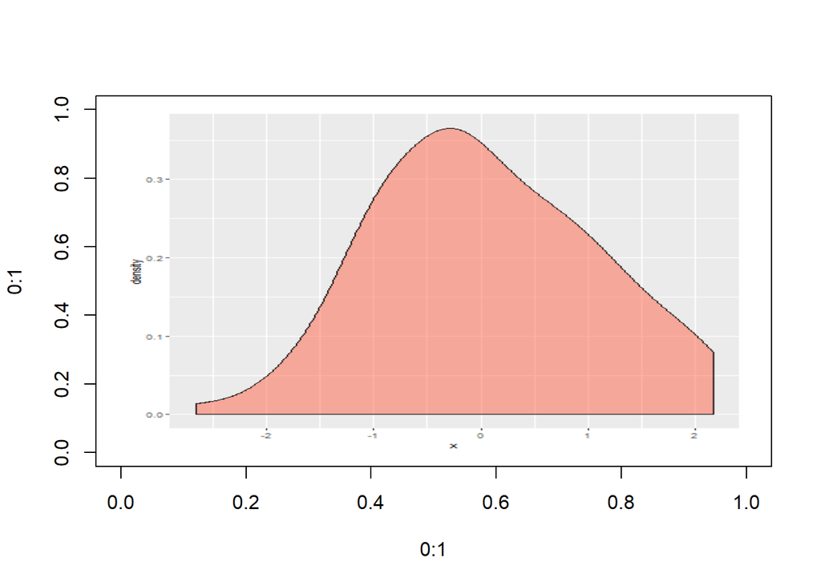

```r
library(httr)
library(tidyverse)

plot(0:1, 0:1, type = "n")

GET('http://localhost:8000/ggplot') %>%
  content() %>% rasterImage(0, 0, 1, 1)
```

`/plot` 서비스는 Base 그래픽으로 결과를 출력하는 사례다.

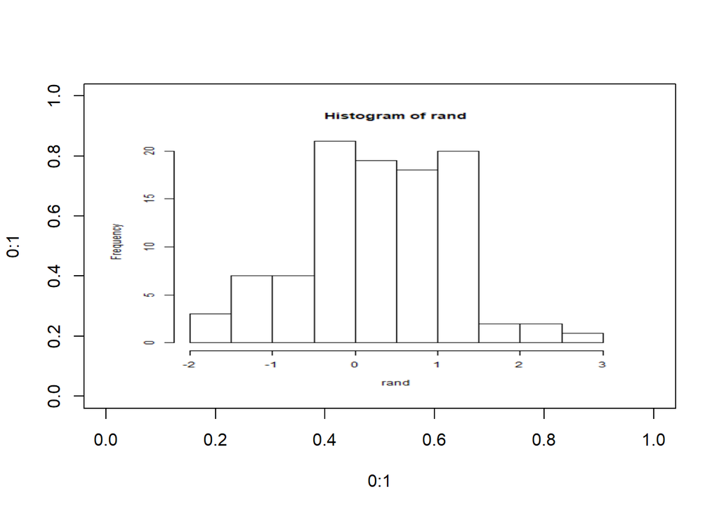

```r
plot(0:1, 0:1, type = "n")

GET('http://localhost:8000/plot') %>%
  content() %>% rasterImage(0, 0, 1, 1)
```

## 1.3 `/sum_two` 그래프

`/sum_two` 서비스는 두개의 값을 받아 더하기 하는 단순한 함수로 입력값을 받아 적절히 처리하는 사례를 모사한다.

```r
GET('http://localhost:8000/sum_two?a=7&b=10') %>%
  content()
```

```
[[1]]
[1] 17
```

# 2 R마크다운 문서 제작

RESTful API를 R마크다운 문서화를 위해서 먼저 제작된 RESTful API를 띄워놓고 이를 R마크다운 문서에서 불러다 호출하는 방식으로 HTML 문서를 제작한다. 이 과정에서 RESTful API 호출결과를 가져올 경우 이를 파싱해서 적절한 형태로 전환시켜야 하는데 이를 위해서 `httr` 팩키지 `content()` 함수와 시각화 객체를 객체를 PNG 파일로 삽입시키는데 `rasterImage()` 함수를 사용한다.

[figure not shown]

`plumber`와 R마크다운